# Tugas2_MPDW

Raden Roro Jessica Faaris

2025-09-03

# Tahap 1: Persiapan Alat dan Data

## Library

```r
library(lmtest)
library(orcutt)
library(HoRM)
```

## Input Data

```r
tahun <- 2004:2013
ipm <- c(67.70, 68.53,  69.21,  69.70,  70.12,  70.42,  70.89,  71.55,  71.99,  72.47)
dt_ipm <- data.frame(tahun, ipm)
dt_ipm
```

```
##    tahun   ipm
## 1   2004 67.70
## 2   2005 68.53
## 3   2006 69.21
## 4   2007 69.70
## 5   2008 70.12
## 6   2009 70.42
## 7   2010 70.89
## 8   2011 71.55
## 9   2012 71.99
## 10  2013 72.47
```

# Tahap 2: Membuat Model Awal

Membuat model regresi linear sederhana untuk memprediksi ipm berdasarkan tahun. Di tahap ini, model diasumsikan baik-baik saja.

```r
# Membuat model regresi OLS (Ordinary Least Squares)
model_awal <- lm(ipm ~ tahun, data = dt_ipm)
summary(model_awal)
```

```
##
## Call:
## lm(formula = ipm ~ tahun, data = dt_ipm)
##
## Residuals:
##      Min       1Q   Median       3Q      Max
## -0.30200 -0.07750  0.00200  0.09417  0.20533
##
## Coefficients:
##               Estimate Std. Error t value Pr(>|t|)
## (Intercept) -936.67000   35.87924  -26.11 4.98e-09 ***
## tahun          0.50133    0.01786   28.06 2.81e-09 ***
## ---
## Signif. codes:  0 '***' 0.001 '**' 0.01 '*' 0.05 '.' 0.1 ' ' 1
##
## Residual standard error: 0.1623 on 8 degrees of freedom
## Multiple R-squared:  0.9899, Adjusted R-squared:  0.9887
## F-statistic: 787.6 on 1 and 8 DF,  p-value: 2.807e-09
```

Nilai Adjusted R-squared sangat tinggi (0.9887) dan koefisien tahun sangat signifikan (p-value < 0.001).

# Tahap 3: Diagnosis

## Diagnosis Visual

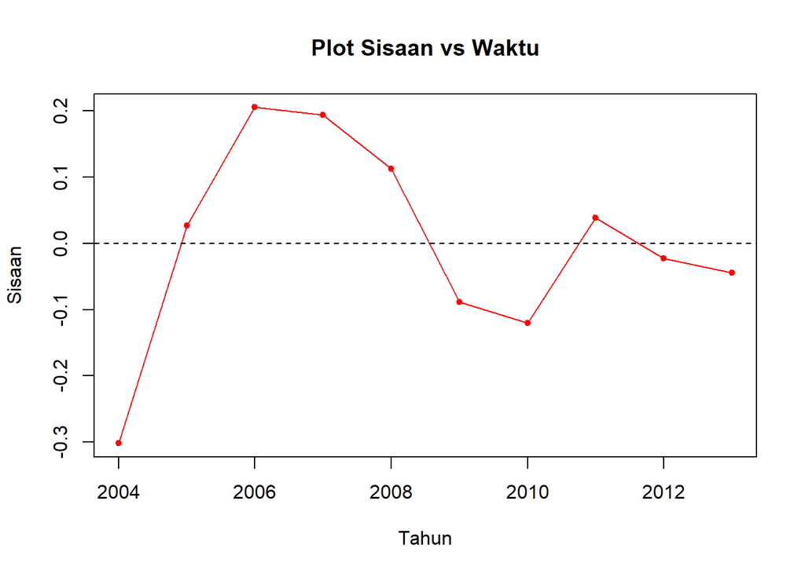

```r
# Ambil sisaan dari model
sisaan_awal <- residuals(model_awal)

# Plot sisaan terhadap waktu
plot(dt_ipm$tahun, sisaan_awal, type="o", pch=20, col="red",
     main="Plot Sisaan vs Waktu", xlab="Tahun", ylab="Sisaan")
abline(h=0, lty=2) # Garis referensi di y=0
```

Pola naik–turun yang berurutan ini **tidak acak**. Sisaan cenderung bergerombol: periode dengan sisaan positif diikuti positif lagi, dan sisaan negatif diikuti negatif lagi.

Artinya, ada indikasi **autokorelasi positif** dalam sisaan, sehingga model regresi linier sederhana mungkin belum sepenuhnya menangkap struktur data deret waktu ini.

## Diagnosis Formal (Uji Durbin-Watson)

- H0 (Hipotesis Nol): Tidak ada autokorelasi. Sisaan saling bebas.
- H1 (Hipotesis Alternatif): Ada autokorelasi.

```r
dwtest(model_awal)
```

```
##
##  Durbin-Watson test
##
## data:  model_awal
## DW = 1.0332, p-value = 0.01238
## alternative hypothesis: true autocorrelation is greater than 0
```

- P-value yang dihasilkan **sangat kecil (0.01238)**, yaitu di bawah tingkat signifikansi 0.05.
- Kesimpulan: Kita **menolak H0**. Model **terbukti menderita autokorelasi**.

# Tahap 4: Penanganan (Penyembuhan Model)

## Metode 1: Cochrane-Orcutt

```r
model_co <- cochrane.orcutt(model_awal)
summary(model_co)
```

```
## Call:
## lm(formula = ipm ~ tahun, data = dt_ipm)
##
##                Estimate  Std. Error t value  Pr(>|t|)
## (Intercept) -862.893466   31.992176 -26.972 2.469e-08 ***
## tahun          0.464640    0.015921  29.184 1.428e-08 ***
## ---
## Signif. codes:  0 '***' 0.001 '**' 0.01 '*' 0.05 '.' 0.1 ' ' 1
##
## Residual standard error: 0.0881 on 7 degrees of freedom
## Multiple R-squared:  0.9918 ,  Adjusted R-squared:  0.9907
## F-statistic: 851.7 on 1 and 7 DF,  p-value: < 1.428e-08
##
## Durbin-Watson statistic
## (original):    1.03315 , p-value: 1.238e-02
## (transformed): 1.59521 , p-value: 1.273e-01
```

```r
# rho paling optimum
rho <- model_co$rho
cat("Rho optimum:", rho)
```

```
## Rho optimum: 0.2855958
```

**Verifikasi Manual:**

```r
ipm.trans <- dt_ipm$ipm[-1] - dt_ipm$ipm[-12]*rho
tahun.trans <- dt_ipm$tahun[-1] - dt_ipm$tahun[-12]*rho
model_co_manual <- lm(ipm.trans~tahun.trans)

b0_co_manual <- coef(model_co_manual)[1]/(1-rho)
b1_co_manual <- coef(model_co_manual)[2]
cat("Koefisien manual Cochrane-Orcutt:\n")
```

```
## Koefisien manual Cochrane-Orcutt:
```

```r
cat("b0:", b0_co_manual, "\n")
```

```
## b0: -895.9094
```

```r
cat("b1:", b1_co_manual, "\n")
```

```
## b1: 0.4810636
```

Hasil koefisien manual kita hampir mirip dengan hasil dari fungsi otomatis, ini dapat terjadi karena fungsi otomatis melakukan beberapa iterasi.

## Metode 2: Hildreth-Lu

```r
#Penanganan Autokorelasi Hildreth lu
# Hildreth-Lu
hildreth.lu.func<- function(r, model){
  x <- model.matrix(model)[,-1]
  y <- model.response(model.frame(model))
  n <- length(y)
  t <- 2:n
  y <- y[t]-r*y[t-1]
  x <- x[t]-r*x[t-1]

  return(lm(y~x))
}

#Pencariab rho yang meminimumkan SSE
r <- c(seq(0.1,0.9, by= 0.1))
tab <- data.frame("rho" = r, "SSE" = sapply(r, function(i){deviance(hildreth.lu.func(i, model_awal))}))
round(tab, 4)
```

```
##   rho    SSE
## 1 0.1 0.0615
## 2 0.2 0.0559
## 3 0.3 0.0544
## 4 0.4 0.0571
## 5 0.5 0.0639
## 6 0.6 0.0749
## 7 0.7 0.0900
## 8 0.8 0.1093
## 9 0.9 0.1327
```

Pada hasil di atas terlihat ρminimum ketika 0.3. Namun, hasil tersebut masih kurang teliti sehingga akan dicari kembali ρ yang lebih optimum dengan ketelitian yang lebih. Jika sebelumnya jarak antar ρ yang dicari adalah 0.1, kali ini jarak antar ρ adalah 0.001 dan dilakukan pada selang 0.2 sampai dengan 0.5.

```r
#Rho optimal di sekitar 0.4
rOpt <- seq(0.2,0.5, by= 0.001)
tabOpt <- data.frame("rho" = rOpt, "SSE" = sapply(rOpt, function(i){deviance(hildreth.lu.func(i, model_awal))}))
head(tabOpt[order(tabOpt$SSE),])
```

```
##      rho        SSE
## 87 0.286 0.05433650
## 86 0.285 0.05433654
## 88 0.287 0.05433688
## 85 0.284 0.05433700
## 89 0.288 0.05433767
## 84 0.283 0.05433787
```

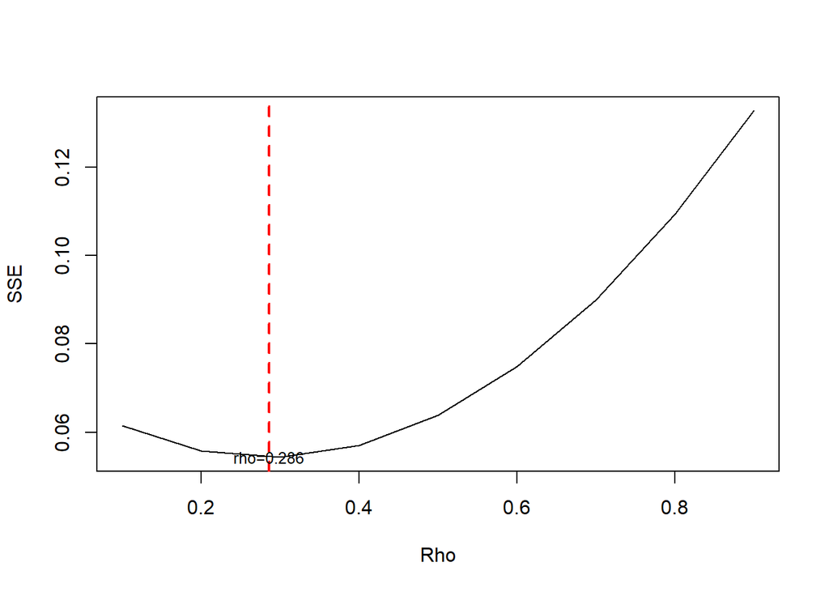

```r
#Grafik SSE optimum
par(mfrow = c(1,1))
plot(tab$SSE ~ tab$rho , type = "l", xlab = "Rho", ylab = "SSE")
abline(v = tabOpt[tabOpt$SSE==min(tabOpt$SSE),"rho"], lty = 2, col="red",lwd=2)
text(x=0.286, y=0.05433650, labels = "rho=0.286", cex = 0.8)
```

```r
model_hl <- hildreth.lu(dt_ipm$ipm, dt_ipm$tahun, rho = 0.286)
summary(model_hl)
```

```
##
## Call:
## lm(formula = y ~ x)
##
## Residuals:
##      Min       1Q   Median       3Q      Max
## -0.15305 -0.02398  0.01276  0.05069  0.09326
##
## Coefficients:
##               Estimate Std. Error t value Pr(>|t|)
## (Intercept) -616.07312   22.85536  -26.95 2.48e-08 ***
## x              0.46462    0.01593   29.17 1.43e-08 ***
## ---
## Signif. codes:  0 '***' 0.001 '**' 0.01 '*' 0.05 '.' 0.1 ' ' 1
##
## Residual standard error: 0.0881 on 7 degrees of freedom
## Multiple R-squared:  0.9918, Adjusted R-squared:  0.9907
## F-statistic: 850.6 on 1 and 7 DF,  p-value: 1.434e-08
```

```r
#Transformasi Balik
cat("y = ", coef(model_hl)[1]/(1-0.286), "+", coef(model_hl)[2],"x", sep = "")
```

```
## y = -862.8475+0.4646172x
```

```r
#Deteksi autokorelasi
dwtest(model_hl)
```

```
##
##  Durbin-Watson test
##
## data:  model_hl
## DW = 1.595, p-value = 0.1273
## alternative hypothesis: true autocorrelation is greater than 0
```

Hasil summary memberikan model akhir yang juga sudah “sehat”, dengan statistik D-W yang sudah membaik.

# Tahap 5: Evaluasi Akhir

Membandingkan SSE dan Statistik Durbin-Watson dari ketiga model untuk melihat seberapa efektif penanganan.

```r
# Menghitung SSE untuk setiap model secara manual
sse_awal <- sum(residuals(model_awal)^2)
sse_co <- sum(residuals(model_co)^2)
sse_hl <- sum(residuals(model_hl)^2)

# Membuat tabel perbandingan
data.frame(
  Metode = c("Model Awal (Sakit)", "Cochrane-Orcutt (Sehat)", "Hildreth-Lu (Sehat)"),
  SSE = c(sse_awal, sse_co, sse_hl),
  DW_Statistic = c(dwtest(model_awal)$statistic, model_co$DW[3], dwtest(model_hl)$statistic)
)
```

```
##                    Metode       SSE DW_Statistic
## 1      Model Awal (Sakit) 0.2106133     1.033154
## 2 Cochrane-Orcutt (Sehat) 0.3825796     1.595213
## 3     Hildreth-Lu (Sehat) 0.0543365     1.595034
```

Keduanya juga berhasil menghilangkan autokorelasi, yang ditunjukkan oleh statistik D-W yang mendekati 2.

Model akhir yang seharusnya kita gunakan adalah salah satu dari model yang telah ditangani, karena estimasi koefisien dan uji signifikansinya sekarang jauh lebih dapat dipercaya.